# Developing a Machine Learning Workflow in AWS

Throughout this project, we will develop a workflow for data preparation, model optimization and training, and endpoint deployment for end-user inference of data samples to be used in classification.

```python
# TODO: Install any packages that you might need
# For instance, you will need the smdebug package
!pip install smdebug
```

```python
# TODO: Import any packages that you might need
# For instance you will need Boto3 and Sagemaker
import sagemaker
import boto3
```

## Dataset

For this project, I don't have an alternate dataset suggestion in mind, so I will follow the default provided dataset. Therefore, I will start by exploring the dataset.

```python
#TODO: Fetch and upload the data to AWS S3

# Command to download and unzip data - note: cleared output after downloading and extracting, to avoid repeating
# !wget https://s3-us-west-1.amazonaws.com/udacity-aind/dog-project/dogImages.zip
# !unzip dogImages.zip

# Now upload to S3 - note cleared below command after running to avoid double sync
# !aws s3 sync dogImages "s3://sagemaker-us-east-1-518267030618/project3/"
```

## Hyperparameter Tuning

**Note:** I began by creating code and debuigging train_model.py, as this is a prerequisite to running hpo.py. There was a lot of Google-searching and external resource-gathering involved, as many of the concepts required were not covered during the lecture material - for example, defining a dataset based on an ImageFolder. This, plus extensive wait times while waiting for estimator.fit() and tuner.fit() to run, only to find some simple syntax error, caused a lot of grief. Therefore, it is paramount to ensure the remote train_model.py script runs correctly first.

```python
from sagemaker.debugger import Rule, DebuggerHookConfig, ProfilerRule, rule_configs

rules = [
    Rule.sagemaker(rule_configs.vanishing_gradient()),
    Rule.sagemaker(rule_configs.overfit()),
    Rule.sagemaker(rule_configs.overtraining()),
    Rule.sagemaker(rule_configs.poor_weight_initialization()),
    Rule.sagemaker(rule_configs.loss_not_decreasing()),
    ProfilerRule.sagemaker(rule_configs.LowGPUUtilization()),
    ProfilerRule.sagemaker(rule_configs.ProfilerReport()),
]

from sagemaker.debugger import ProfilerConfig, FrameworkProfile

debugger_config = DebuggerHookConfig(
    hook_parameters={"train.save_interval": "100", "eval.save_interval": "10"}
)

profiler_config = ProfilerConfig(
    system_monitor_interval_millis=500, framework_profile_params=FrameworkProfile(num_steps=10)
)
```

```python
from sagemaker.pytorch import PyTorch
#TODO: Create estimators for your HPs
#Try to submit just train model by itself first
inputdir='s3://sagemaker-us-east-1-518267030618/project3'
role=sagemaker.get_execution_role()
```

```python
estimator = PyTorch(
    entry_point="train_model.py",
    role=role,
    py_version='py36',
    framework_version="1.8",
    instance_count=1,
    instance_type="ml.g4dn.2xlarge",
    profiler_config=profiler_config,
    debugger_hook_config=debugger_config,
    rules=rules,
)

estimator.fit({
    'train':inputdir+'/test/',
    'test':inputdir+'/test/',
    'val':inputdir+'/test/',
})
```

[output not shown]

[output cut: 109 more lines]

```
Downloading: "https://download.pytorch.org/models/resnet18-5c106cde.pth" to /root/.cache/torch/hub/checkpoints/resnet18-5c106cde.pth
INFO:__main__:Saving the model
2021-12-09 10:55:33,563 sagemaker-training-toolkit INFO     Reporting training SUCCESS

2021-12-09 10:56:04 Uploading - Uploading generated training model
2021-12-09 10:56:04 Completed - Training job completed
VanishingGradient: NoIssuesFound
Overfit: NoIssuesFound
Overtraining: InProgress
PoorWeightInitialization: IssuesFound
LossNotDecreasing: NoIssuesFound
LowGPUUtilization: NoIssuesFound
ProfilerReport: NoIssuesFound
Training seconds: 209
Billable seconds: 209
```

## Review debugging and profiling information

Now that the training job has successfully run on the AWS cluster, we review the results from debugging and profiling, which I had included in this train_model.py script from the beginning.

```python
training_job_name=estimator.latest_training_job.name
print(f"Training name: {training_job_name}")
session=boto3.session.Session()
region=session.region_name
print(f"Region: {region}")
```

```
Training name: pytorch-training-2021-12-09-10-45-00-058
Region: us-east-1
```

```python
from smdebug.trials import create_trial
from smdebug.core.modes import ModeKeys
from smdebug.profiler.analysis.notebook_utils.training_job import TrainingJob
from smdebug.profiler.analysis.notebook_utils.timeline_charts import TimelineCharts
trial=create_trial(estimator.latest_job_debugger_artifacts_path())
print(trial.tensor_names())
print(len(trial.tensor("CrossEntropyLoss_output_0").steps(mode=ModeKeys.TRAIN)))
print(len(trial.tensor("CrossEntropyLoss_output_0").steps(mode=ModeKeys.EVAL)))

tj = TrainingJob(training_job_name, region)
tj.wait_for_sys_profiling_data_to_be_available()

system_metrics_reader = tj.get_systems_metrics_reader()
system_metrics_reader.refresh_event_file_list()

view_timeline_charts = TimelineCharts(
    system_metrics_reader,
    framework_metrics_reader=None,
    select_dimensions=["CPU", "GPU"],
    select_events=["total"],
)

rule_output_path = estimator.output_path + estimator.latest_training_job.job_name + "/rule-output"
print(f"You will find the profiler report in {rule_output_path}")
```

```
[2021-12-09 11:25:06.538 datascience-1-0-ml-t3-medium-1abf3407f667f989be9d86559395:22 INFO utils.py:27] RULE_JOB_STOP_SIGNAL_FILENAME: None
```

```
[2021-12-09 11:25:07.025 datascience-1-0-ml-t3-medium-1abf3407f667f989be9d86559395:22 INFO s3_trial.py:42] Loading trial debug-output at path s3://sagemaker-us-east-1-518267030618/pytorch-training-2021-12-09-10-45-00-058/debug-output
[2021-12-09 11:25:07.571 datascience-1-0-ml-t3-medium-1abf3407f667f989be9d86559395:22 INFO trial.py:198] Training has ended, will refresh one final time in 1 sec.
[2021-12-09 11:25:08.593 datascience-1-0-ml-t3-medium-1abf3407f667f989be9d86559395:22 INFO trial.py:210] Loaded all steps
['CrossEntropyLoss_output_0', 'gradient/ResNet_fc.0.bias', 'gradient/ResNet_fc.0.weight', 'layer1.0.relu_input_0', 'layer1.0.relu_input_1', 'layer1.1.relu_input_0', 'layer1.1.relu_input_1', 'layer2.0.relu_input_0', 'layer2.0.relu_input_1', 'layer2.1.relu_input_0', 'layer2.1.relu_input_1', 'layer3.0.…
1
1
ProfilerConfig:{'S3OutputPath': 's3://sagemaker-us-east-1-518267030618/', 'ProfilingIntervalInMilliseconds': 500, 'ProfilingParameters': {'DataloaderProfilingConfig': '{"StartStep": 0, "NumSteps": 10, "MetricsRegex": ".*", }', 'DetailedProfilingConfig': '{"StartStep": 0, "NumSteps": 10, }', 'FileOpe…
s3 path:s3://sagemaker-us-east-1-518267030618/pytorch-training-2021-12-09-10-45-00-058/profiler-output


Profiler data from system is available
[2021-12-09 11:25:08.751 datascience-1-0-ml-t3-medium-1abf3407f667f989be9d86559395:22 INFO metrics_reader_base.py:134] Getting 4 event files
select events:['total']
select dimensions:['CPU', 'GPU']
filtered_events:{'total'}
filtered_dimensions:{'GPUMemoryUtilization-nodeid:algo-1', 'CPUUtilization-nodeid:algo-1', 'GPUUtilization-nodeid:algo-1'}
```

[interactive chart not shown]

```
You will find the profiler report in s3://sagemaker-us-east-1-518267030618/pytorch-training-2021-12-09-10-45-00-058/rule-output
```

From the data shown, it's apparent that GPU processor and memory utilization were mostly 0 during the logging window, and did pick up slightly towards the end, but never exceeded 20%. This is inline with experience running GPU training locally (~30% utilization max) as well as the general public (https://stackoverflow.com/a/46146814 - one example, though many were found in the course of searching online for GPU utilization deep learning)

## HPO Tuning

Now, we define and run the actual tuning job. Initially I had defined learning rate as a continuous parameter, but this lead to sub-optimal optimization; how could an optimzation algorithm choose from a continuous distribution with only 4 evaluations? I had intended to run 8 total (4 in parallel), but AWS did not allow more than 2 instances in parallel, so I left it with the initial 4 jobs total (2 in parallel).

My choices for hyper parameters are basic, but defining the learning rate as a categorical parameter, using the rule of 3 - increasing the LR by a factor of 3 - provides 3 choices total.

Additionally, too many choices for batch size could lead to suboptimal results from the total optimization space. So here similarly I limited to only 2 possibilities, which should allow the optimizer to better find the best options.

In this example, only 6 total combinations of hyperparameters are possible, and I evaluate 4 total. If this were a real case, I would run many more total cases (at least 8-16), using more levels of each parameter (higher learning rate spread, higher batch-size spread) to get a better assessment of the response.

Initially I set this up with epochs as a further hyperparameter, but given the limited design space, it seemed that with varying epochs would simply improve loss as epochs went up. So I removed epochs and kept it as "5" in the hpo.py file, with the intent to double epochs for finetuning later.

```python
#TODO: Declare your HP ranges, metrics etc.
from sagemaker.tuner import (
    IntegerParameter,
    CategoricalParameter,
    ContinuousParameter,
    HyperparameterTuner,
)

hyperparameter_ranges={
    "lr": CategoricalParameter([0.001,0.003,0.01]),
    "batch-size": CategoricalParameter([8,32])
}

objective_metric_name="average test loss"
objective_type="Minimize"
metric_definitions=[{"Name":"average test loss","Regex":"Test set: Average loss: ([0-9\\.]+)"}]

estimator = PyTorch(
    entry_point="hpo.py",
    role=role,
    py_version='py36',
    framework_version="1.8",
    instance_count=1,
    instance_type="ml.g4dn.xlarge",
    profiler_config=profiler_config,
    debugger_hook_config=debugger_config,
    rules=rules,
)

tuner = HyperparameterTuner(
    estimator,
    objective_metric_name,
    hyperparameter_ranges,
    metric_definitions,
    max_jobs=4,
    max_parallel_jobs=2,
    objective_type=objective_type,
)
```

```python
# TODO: Fit your HP Tuner
tuner.fit({
    'train':inputdir+'/test/',
    'test':inputdir+'/test/',
    'val':inputdir+'/test/',
})
```

```
..................................................................................................................................................................................................................!
```

Now that the HPO is complete, list the best result.

```python
# TODO: Get the best estimators and the best HPs

best_estimator = tuner.best_estimator()

#Get the hyperparameters of the best trained model
best_estimator.hyperparameters()
```

```
2021-12-09 11:42:01 Starting - Preparing the instances for training
2021-12-09 11:42:01 Downloading - Downloading input data
2021-12-09 11:42:01 Training - Training image download completed. Training in progress.
2021-12-09 11:42:01 Uploading - Uploading generated training model
2021-12-09 11:42:01 Completed - Training job completed
```

```
{'_tuning_objective_metric': '"average test loss"',
 'batch-size': '"32"',
 'lr': '"0.01"',
 'sagemaker_container_log_level': '20',
 'sagemaker_estimator_class_name': '"PyTorch"',
 'sagemaker_estimator_module': '"sagemaker.pytorch.estimator"',
 'sagemaker_job_name': '"pytorch-training-2021-12-09-11-25-19-862"',
 'sagemaker_program': '"hpo.py"',
 'sagemaker_region': '"us-east-1"',
 'sagemaker_submit_directory': '"s3://sagemaker-us-east-1-518267030618/pytorch-training-2021-12-09-11-25-19-862/source/sourcedir.tar.gz"'}
```

## Model Profiling and Debugging

**Note:** You will need to use the `train_model.py` script to perform model profiling and debugging.

```python
# TODO: Set up debugging and profiling rules and hooks
from sagemaker.debugger import Rule, DebuggerHookConfig, ProfilerRule, rule_configs

rules = [
    Rule.sagemaker(rule_configs.vanishing_gradient()),
    Rule.sagemaker(rule_configs.overfit()),
    Rule.sagemaker(rule_configs.overtraining()),
    Rule.sagemaker(rule_configs.poor_weight_initialization()),
    Rule.sagemaker(rule_configs.loss_not_decreasing()),
    ProfilerRule.sagemaker(rule_configs.LowGPUUtilization()),
    ProfilerRule.sagemaker(rule_configs.ProfilerReport()),
]

from sagemaker.debugger import ProfilerConfig, FrameworkProfile

debugger_config = DebuggerHookConfig(
    hook_parameters={"train.save_interval": "100", "eval.save_interval": "10"}
)

profiler_config = ProfilerConfig(
    system_monitor_interval_millis=500, framework_profile_params=FrameworkProfile(num_steps=10)
)
```

```python
hyperparameters={"epochs":"10", "batch-size":"32","lr":"0.003"}

estimator = PyTorch(
    entry_point="train_model.py",
    role=role,
    py_version='py36',
    framework_version="1.8",
    instance_count=1,
    instance_type="ml.g4dn.2xlarge",
    hyperparameters=hyperparameters,
    profiler_config=profiler_config,
    debugger_hook_config=debugger_config,
    rules=rules,
)

estimator.fit({
    'train':inputdir+'/test/',
    'test':inputdir+'/test/',
    'val':inputdir+'/test/',
})
```

[output not shown]

[output cut: 116 more lines]

```
Saving the model
Downloading: "https://download.pytorch.org/models/resnet18-5c106cde.pth" to /root/.cache/torch/hub/checkpoints/resnet18-5c106cde.pth
INFO:__main__:Saving the model
2021-12-09 11:54:19,452 sagemaker-training-toolkit INFO     Reporting training SUCCESS

2021-12-09 11:54:47 Completed - Training job completed
VanishingGradient: NoIssuesFound
Overfit: NoIssuesFound
Overtraining: NoIssuesFound
PoorWeightInitialization: InProgress
LossNotDecreasing: NoIssuesFound
LowGPUUtilization: NoIssuesFound
ProfilerReport: NoIssuesFound
Training seconds: 405
Billable seconds: 405
```

```python
estimator.hyperparameters()
```

```
{'epochs': '"10"',
 'batch-size': '"32"',
 'lr': '"0.003"',
 'sagemaker_submit_directory': '"s3://sagemaker-us-east-1-518267030618/pytorch-training-2021-12-09-11-45-21-838/source/sourcedir.tar.gz"',
 'sagemaker_program': '"train_model.py"',
 'sagemaker_container_log_level': '20',
 'sagemaker_job_name': '"pytorch-training-2021-12-09-11-45-21-838"',
 'sagemaker_region': '"us-east-1"'}
```

```python
# TODO: Plot a debugging output.

training_job_name=estimator.latest_training_job.name
print(f"Training name: {training_job_name}")
session=boto3.session.Session()
region=session.region_name
print(f"Region: {region}")
```

```
Training name: pytorch-training-2021-12-09-11-45-21-838
Region: us-east-1
```

```python
from smdebug.trials import create_trial
from smdebug.core.modes import ModeKeys
from smdebug.profiler.analysis.notebook_utils.training_job import TrainingJob
from smdebug.profiler.analysis.notebook_utils.timeline_charts import TimelineCharts
trial=create_trial(estimator.latest_job_debugger_artifacts_path())
print(trial.tensor_names())
print(len(trial.tensor("CrossEntropyLoss_output_0").steps(mode=ModeKeys.TRAIN)))
print(len(trial.tensor("CrossEntropyLoss_output_0").steps(mode=ModeKeys.EVAL)))

tj = TrainingJob(training_job_name, region)
tj.wait_for_sys_profiling_data_to_be_available()

system_metrics_reader = tj.get_systems_metrics_reader()
system_metrics_reader.refresh_event_file_list()
```

```
[2021-12-09 11:55:20.081 datascience-1-0-ml-t3-medium-1abf3407f667f989be9d86559395:22 INFO s3_trial.py:42] Loading trial debug-output at path s3://sagemaker-us-east-1-518267030618/pytorch-training-2021-12-09-11-45-21-838/debug-output
[2021-12-09 11:55:20.328 datascience-1-0-ml-t3-medium-1abf3407f667f989be9d86559395:22 INFO trial.py:198] Training has ended, will refresh one final time in 1 sec.
[2021-12-09 11:55:21.348 datascience-1-0-ml-t3-medium-1abf3407f667f989be9d86559395:22 INFO trial.py:210] Loaded all steps
['CrossEntropyLoss_output_0', 'gradient/ResNet_fc.0.bias', 'gradient/ResNet_fc.0.weight', 'layer1.0.relu_input_0', 'layer1.0.relu_input_1', 'layer1.1.relu_input_0', 'layer1.1.relu_input_1', 'layer2.0.relu_input_0', 'layer2.0.relu_input_1', 'layer2.1.relu_input_0', 'layer2.1.relu_input_1', 'layer3.0.…
1
1
ProfilerConfig:{'S3OutputPath': 's3://sagemaker-us-east-1-518267030618/', 'ProfilingIntervalInMilliseconds': 500, 'ProfilingParameters': {'DataloaderProfilingConfig': '{"StartStep": 0, "NumSteps": 10, "MetricsRegex": ".*", }', 'DetailedProfilingConfig': '{"StartStep": 0, "NumSteps": 10, }', 'FileOpe…
s3 path:s3://sagemaker-us-east-1-518267030618/pytorch-training-2021-12-09-11-45-21-838/profiler-output


Profiler data from system is available
```

```python
view_timeline_charts = TimelineCharts(
    system_metrics_reader,
    framework_metrics_reader=None,
    select_dimensions=["CPU", "GPU"],
    select_events=["total"],
)

rule_output_path = estimator.output_path + estimator.latest_training_job.job_name + "/rule-output"
print(f"You will find the profiler report in {rule_output_path}")
```

```
[2021-12-09 11:55:25.735 datascience-1-0-ml-t3-medium-1abf3407f667f989be9d86559395:22 INFO metrics_reader_base.py:134] Getting 8 event files
select events:['total']
select dimensions:['CPU', 'GPU']
filtered_events:{'total'}
filtered_dimensions:{'GPUMemoryUtilization-nodeid:algo-1', 'CPUUtilization-nodeid:algo-1', 'GPUUtilization-nodeid:algo-1'}
```

[interactive chart not shown]

```
You will find the profiler report in s3://sagemaker-us-east-1-518267030618/pytorch-training-2021-12-09-11-45-21-838/rule-output
```

**TODO**: Is there some anomalous behaviour in your debugging output? If so, what is the error and how will you fix it?

GPU memory / processor utilization both seem typical for the training cases that were run, as was the case previously and seems to be the general experience (GPU utilization is relatively low unless when the use case is optimized for both GPU core and memory utilization). Towards the end of the time window, they are all near 15-20%.

**TODO**: If not, suppose there was an error. What would that error look like and how would you have fixed it?

If there was an issue, we could see these drop to 0 for some time while the training job was still running; in which case, I would have to revert back to debugging the train_model.py script to see why GPU usage was quite low.

```python
# TODO: Display the profiler output
import os

# get the autogenerated folder name of profiler report
profiler_report_name = [
    rule["RuleConfigurationName"]
    for rule in estimator.latest_training_job.rule_job_summary()
    if "Profiler" in rule["RuleConfigurationName"]
][0]
print(profiler_report_name)

# actual path - s3://sagemaker-us-east-1-359967743302/pytorch-training-2021-12-06-11-08-09-203/rule-output/ProfilerReport/profiler-output/profiler-report.html

profiler_report_path_s3=rule_output_path + "/"+profiler_report_name+"/profiler-output/"
```

```
ProfilerReport
```

```python
# Copy the profiler report locally
!aws s3 sync {profiler_report_path_s3} "profiler-output"
```

[output not shown]

```python
import IPython

IPython.display.HTML("profiler-output/profiler-report.html")
```

SageMaker Debugger Profiling Report

SageMaker Debugger auto generated this report. You can generate similar reports on all supported training jobs. The report provides summary of training job, system resource usage statistics, framework metrics, rules summary, and detailed analysis from each rule. The graphs and tables are interactive.

**Legal disclaimer:** This report and any recommendations are provided for informational purposes only and are not definitive. You are responsible for making your own independent assessment of the information.

```
# Parameters
processing_job_arn = "arn:aws:sagemaker:us-east-1:518267030618:processing-job/pytorch-training-2021-12-0-profilerreport-629d3418"
```

Training job summary

[interactive chart not shown]

System usage statistics

[interactive chart not shown]

Framework metrics summary

[interactive chart not shown]

Overview: CPU operators

[interactive chart not shown]

Overview: GPU operators

[interactive chart not shown]

Rules summary

The following table shows a profiling summary of the Debugger built-in rules. The table is sorted by the rules that triggered the most frequently. During your training job, the CPUBottleneck rule was the most frequently triggered. It processed 752 datapoints and was triggered 0 times.

|  | Description | Recommendation | Number of times rule triggered | Number of datapoints | Rule parameters |
| --- | --- | --- | --- | --- | --- |
| CPUBottleneck | Checks if the CPU utilization is high and the GPU utilization is low. It might indicate CPU bottlenecks, where the GPUs are waiting for data to arrive from the CPUs. The rule evaluates the CPU and GPU… | Consider increasing the number of data loaders or applying data pre-fetching. | 0 | 752 | threshold:50 cpu_threshold:90 gpu_threshold:10 patience:1000 |
| LoadBalancing | Detects workload balancing issues across GPUs. Workload imbalance can occur in training jobs with data parallelism. The gradients are accumulated on a primary GPU, and this GPU might be overused with … | Choose a different distributed training strategy or a different distributed training framework. | 0 | 742 | threshold:0.2 patience:1000 |
| StepOutlier | Detects outliers in step duration. The step duration for forward and backward pass should be roughly the same throughout the training. If there are significant outliers, it may indicate a system stall… | Check if there are any bottlenecks (CPU, I/O) correlated to the step outliers. | 0 | 238 | threshold:3 mode:None n_outliers:10 stddev:3 |
| LowGPUUtilization | Checks if the GPU utilization is low or fluctuating. This can happen due to bottlenecks, blocking calls for synchronizations, or a small batch size. | Check if there are bottlenecks, minimize blocking calls, change distributed training strategy, or increase the batch size. | 0 | 742 | threshold_p95:70 threshold_p5:10 window:500 patience:1000 |
| IOBottleneck | Checks if the data I/O wait time is high and the GPU utilization is low. It might indicate IO bottlenecks where GPU is waiting for data to arrive from storage. The rule evaluates the I/O and GPU utili… | Pre-fetch data or choose different file formats, such as binary formats that improve I/O performance. | 0 | 752 | threshold:50 io_threshold:50 gpu_threshold:10 patience:1000 |
| MaxInitializationTime | Checks if the time spent on initialization exceeds a threshold percent of the total training time. The rule waits until the first step of training loop starts. The initialization can take longer if do… | Initialization takes too long. If using File mode, consider switching to Pipe mode in case you are using TensorFlow framework. | 0 | 238 | threshold:20 |
| BatchSize | Checks if GPUs are underutilized because the batch size is too small. To detect this problem, the rule analyzes the average GPU memory footprint, the CPU and the GPU utilization. | The batch size is too small, and GPUs are underutilized. Consider running on a smaller instance type or increasing the batch size. | 0 | 741 | cpu_threshold_p95:70 gpu_threshold_p95:70 gpu_memory_threshold_p95:70 patience:1000 window:500 |
| Dataloader | Checks how many data loaders are running in parallel and whether the total number is equal the number of available CPU cores. The rule triggers if number is much smaller or larger than the number of a… | Change the number of data loader processes. | 0 | 10 | min_threshold:70 max_threshold:200 |
| GPUMemoryIncrease | Measures the average GPU memory footprint and triggers if there is a large increase. | Choose a larger instance type with more memory if footprint is close to maximum available memory. | 0 | 742 | increase:5 patience:1000 window:10 |

Analyzing the training loop

Step duration analysis

[interactive chart not shown]

**Step durations on node algo-1-26:**

The following table is a summary of the statistics of step durations measured on node algo-1-26. The rule has analyzed the step duration from Step:ModeKeys.TRAIN phase. The average step duration on node algo-1-26 was 0.1s. The rule detected 1 outliers, where step duration was larger than 3 times the standard deviation of 0.67s

|  | mean | max | p99 | p95 | p50 | min |
| --- | --- | --- | --- | --- | --- | --- |
| Step Durations in [s] | 0.10 | 9.88 | 1.20 | 0.01 | 0.01 | 0.01 |

The following histogram shows the step durations measured on the different nodes. You can turn on or turn off the visualization of histograms by selecting or unselecting the labels in the legend.

[interactive chart not shown]

GPU utilization analysis

**Usage per GPU**

[interactive chart not shown]

**Workload balancing**

[interactive chart not shown]

Dataloading analysis

[interactive chart not shown]

Batch size

[interactive chart not shown]

CPU bottlenecks

[interactive chart not shown]

I/O bottlenecks

[interactive chart not shown]

GPU memory

[interactive chart not shown]

[figure not shown]

## Model Deploying

```python
print("IPython changed the BG color, and I couldn't figure out how to change it back, so I reverted to the light Jupyterlab theme")
```

```
IPython changed the BG color, and I couldn't figure out how to change it back, so I reverted to the light Jupyterlab theme
```

## Model Deployment Woes

There were many challenges to getting a model to deploy, and little debugging information given by AWS.

First, I was using the same ml.g4dn instance to provide GPU inference. However, there was an issue loading smdebug (from my train_models.py script, which worked fine while traininG). But, AWS CloudWatch did not give any information on this error; I sat there, burning g4dn inference hours, trying to debug my model, setup, learn the whole method for deploying models via a .py script (as it was not taught in class).

Eventually, after trying the model on a ml.m5.xlarge endpoint, I finally got the error about smdebug; I removed those lines and re-trained the model, re-deployed the endpoint, to get another error about hooks not being defined.

At this point, my AWS session burned through $25 of costs, so I had to go back to the session from a previous course. However, there while training, the model was not deploying correctly still.

Finally, I manually created my own model.tar.gz using the model.pth and a custom endpoint.py file; I manually created a model within Sagemaker (external to this notebook), and deployed an endpoint. Therefore, "deployment" is covered externally and here I simply refer to the deployed endpoint.

```python
print(sagemaker.session.Session())
```

```
<sagemaker.session.Session object at 0x7fc6bbae2790>
```

```python
from sagemaker.serializers import NumpySerializer
npserializer=NumpySerializer()

from sagemaker.deserializers import NumpyDeserializer
npdeserializer=NumpyDeserializer()
```

```python
# TODO: Deploy your model to an endpoint

# predictor=estimator.deploy(initial_instance_count=1, instance_type="ml.m5.xlarge") # TODO: Add your deployment configuration like instance type and number of instances
from sagemaker.predictor import Predictor
# predictor=Predictor(endpoint_name="dog-inference-endpoint-2",sagemaker_session=session)
predictor=Predictor(endpoint_name="dog-inference-endpoint-2",serializer=npserializer, deserializer=npdeserializer)
```

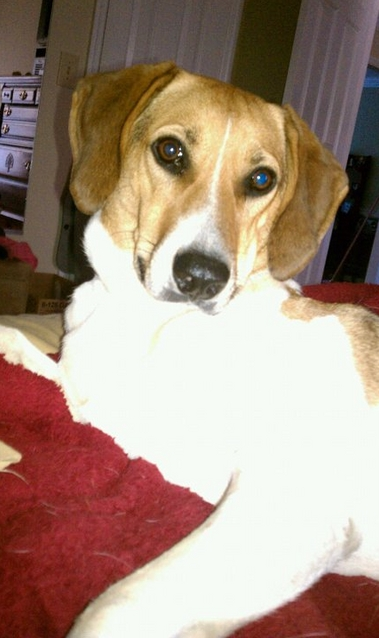

```python
imagepath="./dogImages/test/007.American_foxhound/American_foxhound_00535.jpg"

from IPython.display import Image as showimage
showimage(imagepath)
```

```python
from PIL import Image
from numpy import asarray
pilimage=Image.open(imagepath)


# summarize some details about the image
print(pilimage.format)
print(pilimage.size)
print(pilimage.mode)

nparray=asarray(pilimage)
print(type(nparray))
print(nparray.shape)
```

```
JPEG
(379, 638)
RGB
<class 'numpy.ndarray'>
(638, 379, 3)
```

```python
# !pip install torchvision
```

```python
import torchvision.transforms as transforms
testing_transform = transforms.Compose([
    transforms.RandomResizedCrop(224),
    transforms.ToTensor()])
# help(testing_transform)
image=testing_transform(pilimage) # TODO: Your code to load and preprocess image to send to endpoint for prediction
# response = predictor.predict(image)
print(image.shape)
nparray=asarray(image)
print(image.shape)
```

```
torch.Size([3, 224, 224])
torch.Size([3, 224, 224])
```

```python
np4d=np.expand_dims(nparray,0)
```

```python
import numpy as np
response=predictor.predict(np4d)
```

```python
import torch
print(response)
```

```
[[-19.24454498 -10.21196747  -9.71731186  -6.31578302  -9.92857075
  -14.68026733   2.89591217  -6.12619114 -15.13903809  -5.75525808
   -9.80964279  -9.4243536  -14.95791435  -4.73434258  -4.51998997
   -3.67205501 -17.33584213 -14.7262001  -15.07978439 -10.0279026
  -13.27546597 -14.88987541 -10.59854031 -13.28900909 -15.63776398
  -20.67746544 -12.86298084  -9.45593929 -11.65066242 -13.24253559
   -9.0952816  -14.40761566 -18.78261375  -9.82213879 -12.4458189
  -15.17375946 -11.34447861 -14.94739914 -10.54143143 -12.04625034
  -13.88104439 -14.21073151  -5.25036716 -15.56847095  -7.1262145
   -9.02436924 -12.65603924 -10.83073521 -10.14859104 -12.6882782
  -10.35359478 -13.21957493  -9.31166267  -7.13963079 -13.75203323
   -8.7455101   -9.59419918 -11.6744585  -11.11966228 -13.61985016
  -16.42849159  -9.42277813 -11.04490852 -12.92827988  -8.65130424
  -17.56201553  -9.30608463 -10.68395233 -14.59671402 -13.90233517
  -11.18843079 -13.80804348 -13.95497513 -18.38342667 -13.16630077
   -6.00869894 -14.0392952  -12.59518719  -9.59229183 -10.50065136
  -11.05104637 -12.08474159 -11.30158997  -7.36622334  -6.30078268
   -8.36997414 -10.67494869 -12.59751511 -13.64866161  -9.94509125
  -16.18951607 -17.99134636 -17.64957428 -15.23517609  -9.66331768
   -6.67518997 -14.29231644 -15.18155003 -14.60916519 -16.54095459
  -12.68600082 -12.79952335 -15.29158878 -15.75668335 -17.67355537
  -15.09377384 -13.80240631  -9.40062046 -14.80544281  -5.32184649
  -13.7612524   -6.631423   -11.81441593 -14.83323002  -9.31498814
   -6.39884996 -12.15845203  -5.57551861 -11.96852684 -12.57387257
  -10.01519203 -13.87322235 -13.48696613 -10.65210629 -16.78303337
  -15.08024216 -13.53032207 -12.08549595  -6.53852224 -11.11828423
  -14.15638828 -14.88400364 -14.62764835]]
```

```python
pred=np.argmax(response)+1
print("Predicted class is: "+str(pred))
print("File path, including image class 007.American_foxhound is: "+imagepath)
print("The predicted class is correct.")
```

```
Predicted class is: 7
File path, including image class 007.American_foxhound is: ./dogImages/test/007.American_foxhound/American_foxhound_00535.jpg
The predicted class is correct.
```

```
In this image, the highest dot is the 7th label prediction - our American Foxhound!
```

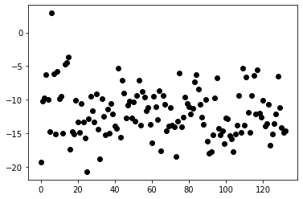

```python
x=range(133)
import matplotlib.pyplot as plt
plt.plot(x,response[0],'o',color='black')
print("In this image, the highest dot is the 7th label prediction - our American Foxhound!")
```

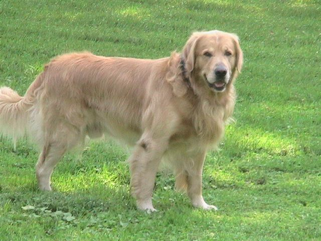

```python
showimage("./dogImages/test/076.Golden_retriever/Golden_retriever_05258.jpg")
```

```
Predicted class is: 76
File path, including image class is: ./dogImages/test/076.Golden_retriever/Golden_retriever_05258.jpg
```

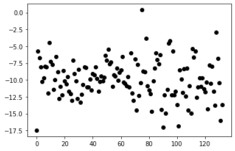

```python
def predict_image_from_path(imagepath2):
    pilimage2=Image.open(imagepath2)
    image2=testing_transform(pilimage2)
    nparray2=asarray(image2)
    np4d2=np.expand_dims(nparray2,0)
    response2=predictor.predict(np4d2)
    x=range(133)
    plt.plot(x,response2[0],'o',color='black')
    pred2=np.argmax(response2)+1
    print("Predicted class is: "+str(pred2))
    print("File path, including image class is: "+imagepath2)
    return response2
response2=predict_image_from_path("./dogImages/test/076.Golden_retriever/Golden_retriever_05258.jpg")
```

Interesting values which are relatively high - near 130 - what indices exactly?

```python
for index,val in np.ndenumerate(response2):
    if val>-5.0:
        print(str(index)+" index - "+str(val)+" value!")
```

```
(0, 9) index - -4.4662299156188965 value!
(0, 75) index - 0.3889547288417816 value!
(0, 78) index - -3.8179714679718018 value!
(0, 94) index - -4.530196666717529 value!
(0, 95) index - -4.162237644195557 value!
(0, 128) index - -2.90712833404541 value!
```

Index 129 is Tibetan Mastiff - does it look like a Golden Retriever?

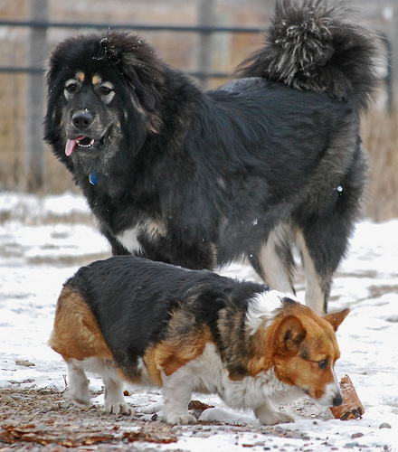

```python
showimage("./dogImages/test/129.Tibetan_mastiff/Tibetan_mastiff_08156.jpg")
```

It does look like a Golden Retriever! The face shape (eyes, snout, nose) resemble a Golden Retriever.

```python
# TODO: Remember to shutdown/delete your endpoint once your work is done
# predictor.delete_endpoint()
```